# An exploration of IMDB data using machine learning techniques

## Introduction

The film industry receives substantial annual box office revenue which is a motivation for analysing the factors influencing the financial success of films. In 2012 revenues exceeded \$10.8 Billion (US/Canada) but despite this there are unsuccessful movies released almost every year (Lash and Zhao, 2016). By identifying the variables that contribute toward profitability it can reduce the risk of production companies releasing a ‘flop’. In this report IMDB data was used to perform machine learning techniques in order to address this issue.

This report establishes what is known in literature about modelling the success of movies. The data is explored via univariate and bivariate analysis. Clustering is performed to understand patterns in movie preferences. Regression analysis is performed to predict revenue. The models are then evaluated with discussions on their implications.

## Literature review

Previous studies have investigated the variables determining the success of a film, they can be used to guide the selection of variables for clustering and predictors in regression analysis. The literature suggests a film’s success is influenced by star power, genre, director and viewer ratings. Meenakshi et al. (2018) used k-means clustering to gauge a film’s success via generating clusters of 3 categories; ‘Flop’, ‘Average’, ‘Hit’. The study used popular actors, genres and composers to produce clusters. Krushikanth et al. (2013) used k-means clustering to show how online rating and sentiment, on platforms such as YouTube, predict a film’s success. Song and Hana (2013) found determinants of financial success may include star actors, release date, rating and whether it is a sequel. Lash and Zhao (2016) highlight the importance of ‘star power’ where individual actors have a name brand effect improving financial performance.

## The dataset

This study used IMDB datasets containing ‘summary’ and ‘rating’ data related to 85,855 films. In order to enable greater specificity not every film was considered. The dataset was filtered to ensure films were a USA release, feature length, the profits and budgets were USD, release date was after 1990, it had over 100 votes. These filters reduced the dataset to 5,829 films. These filters were set to guarantee films were established full length theatrical releases and mitigate issues regarding currency exchange rates and financial inflation. This dataset was supplemented by a list containing the top 100 most lucrative film stars. It is key to highlight that one film can have multiple genres. The core genres and production_companies were derived from those most abundant.

```python
#Load Packages

#used for working with dataframes
import pandas as pd
#used for running SQL queries
import pandasql as ps
#for replicating a consistent outcome
from numpy.random import seed
#for generating clusters
from sklearn.cluster import KMeans
#used for finding the optimum number of clusters
from sklearn.metrics import silhouette_score, calinski_harabasz_score
#used for principle component analysis
from sklearn.decomposition import PCA
#used for normalising the data
from sklearn.preprocessing import scale, MinMaxScaler
# used for generating plots
import seaborn as sns
#general visualisation utilities
import matplotlib.pyplot as plt
#library used for working with arrays
import numpy as np
from sklearn.datasets import make_classification
#for BIRCH cluster model
from sklearn.cluster import Birch
#linear regression model package
import statsmodels.formula.api as sm
from IPython.display import Image
#for building linear regression model
from sklearn.linear_model import LinearRegression
#for building random forest model
from sklearn.ensemble import RandomForestRegressor
#for building random forest model
from sklearn.ensemble import RandomForestClassifier
#for retrieving statitical metrics from supervised learning models
from sklearn import metrics
#specific packages within sklearn for mean sqaure error
from sklearn.metrics import mean_squared_error as mse
#specfic functions within numpy for log transforming, sqrt and generating exponent
from numpy import exp, log1p, sqrt
#function for genersting r-squared score
from sklearn.metrics import r2_score
#for splitting the data into training and testing sets
from sklearn.model_selection import train_test_split
#for generating cross-validation scores
from sklearn.model_selection import cross_val_score
```

### Reading and Manipulating Data

```python
#Loading Datasets
#dataset containing movies and associated information from imdb
movies = pd.read_csv("C:\\Users\\ant-r\\data_science_studio-master\\data_science_studio-master\\docs\\_sources\\content\\Assessment\\IMDb movies.csv\\IMDb movies.csv")
#dataset containing movie review ratings and informations on those reviewers
ratings = pd.read_csv("C:\\Users\\ant-r\\data_science_studio-master\\data_science_studio-master\\docs\\_sources\\content\\Assessment\\IMDb ratings.csv\\IMDb ratings.csv")
#csv of oscar winning actors and actresses
stars = pd.read_csv("Oscar_Winning_Actors_Actresses.csv", encoding= 'cp1252')
#make that CSV a list of names
stars = stars['Name'].tolist()
#csv containing the most financially successful actors and actresses
popular_stars = pd.read_csv("PopularStars.csv")
#make that CSV a list of names
popular_stars = popular_stars['Name'].tolist()
#dataset containing oscar winning directors
stars_directors = pd.read_csv("Oscar_Winning_Directors.csv", encoding= 'cp1252')
#make that CSV a list of names
stars_directors = stars_directors['Name'].tolist()
#join the movies and ratings datasets
dbj1 = movies.join(ratings.set_index("imdb_title_id"), on = "imdb_title_id")
```

```python
#filter dataframes
#SQL query to ensure all films are USA based for direct comparisson
q1 = """SELECT * FROM dbj1 WHERE country like '%USA%'"""
dbj1_world_dollars = ps.sqldf(q1)
#SQL query to  refine dataframe to only contain US dollars
q2 = """SELECT * FROM dbj1_world_dollars WHERE worlwide_gross_income LIKE '$%' AND budget LIKE '$%' """
dbj1_world_dollars = ps.sqldf(q2)
```

```python
#make the pricing attributes a float type removing the $ sign and making a float
dbj1_world_dollars['worlwide_gross_income'] = dbj1_world_dollars['worlwide_gross_income'].astype("string")
dbj1_world_dollars['budget'] = dbj1_world_dollars['budget'].astype("string")
dbj1_world_dollars['worlwide_gross_income'] = dbj1_world_dollars['worlwide_gross_income'].str.replace('$', '').astype(float)
dbj1_world_dollars['budget'] = dbj1_world_dollars['budget'].str.replace('$', '').astype(float)

#make the year attribute an integer and filter to only include films post 1990
dbj1_world_dollars['year'] = dbj1_world_dollars['year'].astype(int)
dbj1_world_dollars = dbj1_world_dollars[dbj1_world_dollars['year'] > 1990]
#ensure films in study have substancial votes more than 100
dbj1_world_dollars = dbj1_world_dollars[dbj1_world_dollars['votes']>100]
```

```python
#investigation of film data using sql queries for ESDA
#SQL query to identify directors that on avergage have the best revenue
q3 = """SELECT director, avg(worlwide_gross_income) FROM dbj1_world_dollars group by director ORDER BY 2 DESC"""
avg_income_directors = ps.sqldf(q3)
#SQL query to identify directors that have the most revenue (max)
q4 = """SELECT director, max(worlwide_gross_income),original_title FROM dbj1_world_dollars group by director ORDER BY 2 DESC"""
max_director = ps.sqldf(q4)
#SQL query to identify directors that on average have the highest review scores
q9 = """SELECT director, avg(mean_vote) FROM dbj1_world_dollars group by director ORDER BY 2 DESC"""
avg_vote_director = ps.sqldf(q9)
#find the most prevelent production companies (top 10)
q10 = """SELECT production_company, count(*) FROM dbj1_world_dollars group by production_company ORDER BY 2 DESC"""
prod = ps.sqldf(q10).head(10)


#generate list of these production companies
prod_series = prod['production_company'].tolist()

#function for using the list of top production companies to refine the list to just include the top 10 or other.
def my_recode(production_company):
    if production_company in prod_series:
        return production_company
    else:
        return 'other'
#generate recoded production company column
dbj1_world_dollars['production_company_R'] = dbj1_world_dollars['production_company'].apply(my_recode)

#edit the actor, director and genre attributes to be a list of values rather than one string
dbj1_world_dollars['actors'] = dbj1_world_dollars['actors'].str.split(', ')
dbj1_world_dollars['genre'] = dbj1_world_dollars['genre'].str.split(', ')
dbj1_world_dollars['director'] = dbj1_world_dollars['director'].str.split(', ')

#drop the rows with an NA actors list
dbj1_world_dollars = dbj1_world_dollars.dropna(subset=['actors'])

#function for when a movie contains an oscar winning actor or actress in the cast this attribute gets a value of 1
def my_recode2(actor):
    for actor in actor:
        if actor in stars:
            return 1
        else:
            return 0

#run the function on the data to generate a column of oscor winning actors
dbj1_world_dollars['oscar_winner_actor'] = dbj1_world_dollars['actors'].apply(my_recode2)

#run the function on the data to generate a column of popular actors
def my_recode5(actor):
    for actor in actor:
        if actor in popular_stars:
            return 1
        else:
            return 0
#run the function on the data to generate a column of star actors
dbj1_world_dollars['star_actor'] = dbj1_world_dollars['actors'].apply(my_recode5)

#function for when a movie contains an oscar winning dirctor this attribute gets a value of 1
def my_recode3(director):
    for director in director:
        if director in stars_directors:
            return 1
        else:
            return 0

#run the function on the data to generate a column of oscor winning directors
dbj1_world_dollars['oscar_winner_director'] = dbj1_world_dollars['director'].apply(my_recode3)
```

```python
#The categorical variable genre was split into a set of binary dummy variables. Due to the excessive number of genres (19) and production_company only the core categories were retained
#The rest were recoded as ‘other’.
#genreate a list of core genres
core_genres = ['Drama', 'Action', 'Comedy', 'Animation','Romance','Family','Horror', 'Crime']
#function to class other non-core categories
def my_recode4(genre):
    for genre in genre:
        if genre in core_genres:
            return 0
        else:
            return 1
#building dummy variables for genres by frist splitting the string list
test = dbj1_world_dollars.genre.str.join('|').str.get_dummies()
test =  test.groupby(by=test.columns, axis=1).sum()
#create an other_genre class for the non core genres
dbj1_world_dollars['other_genre'] =  dbj1_world_dollars['genre'].apply(my_recode4)
dbj1_world_dollars = dbj1_world_dollars.join(test)
#building dummy variables for production comp
test2 = pd.get_dummies(dbj1_world_dollars[['production_company_R']] )
test2 =  test2.groupby(by=test2.columns, axis=1).sum()
dbj1_world_dollars = dbj1_world_dollars.join(test2)
#drop remaining non-core genres
dbj1_world_dollars = dbj1_world_dollars.drop(['Biography','Western','War','Sport','Sci-Fi','Musical','Music','History'], axis=1)
#reset index
dbj1_world_dollars = dbj1_world_dollars.reset_index(drop=True)
#make director a string type
dbj1_world_dollars['director'] = dbj1_world_dollars['director'].astype("string")
#categories to be used for clustering
movie_categories = ['females_allages_avg_vote','males_allages_avg_vote', 'top1000_voters_rating', 'l_budget']
#drop remaining na values
dbj1_world_dollars = dbj1_world_dollars.dropna(subset=['allgenders_18age_avg_vote', 'males_18age_avg_vote', 'females_18age_avg_vote', 'females_45age_avg_vote'])
```

```python
#generate profit and loss attribute
dbj1_world_dollars['profit_margin'] = dbj1_world_dollars['worlwide_gross_income'] - dbj1_world_dollars['budget']
#normalising the pricing variables by using log transformation
dbj1_world_dollars['l_worlwide_gross_income'] = np.log1p(dbj1_world_dollars['worlwide_gross_income'])
#normalising the pricing variables by using log transformation
dbj1_world_dollars['l_budget'] = np.log1p(dbj1_world_dollars['budget'])
#normalising the votes variable by using log transformation
dbj1_world_dollars['l_votes'] = np.log1p(dbj1_world_dollars['votes'])
```

## Exploratory Data Analysis (ESDA)

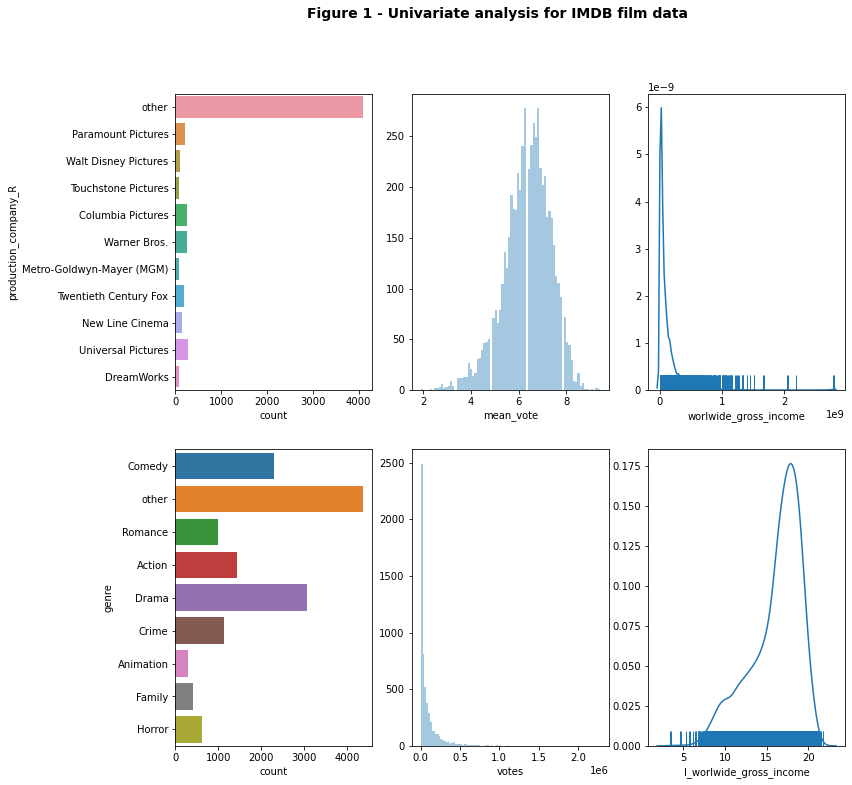

```python
#plot univariate analysis
dbj1_exploded = dbj1_world_dollars.explode('genre')
#function to recode non core genres as 'other'
def my_recode5(genre):
        if genre in core_genres:
            return genre
        else:
            return 'other'

dbj1_exploded['genre'] =  dbj1_exploded['genre'].apply(my_recode5)

#set up figure and 2x3 subplot axes, 12x12 size
f, axs = plt.subplots(2, 3, figsize=(12, 12))

#distribution of votes#distribution of production companies
sns.countplot(y = "production_company_R" , data = dbj1_world_dollars, ax=axs[0,0])
#distribution of worldwide gross income
sns.distplot(dbj1_world_dollars['worlwide_gross_income'],
             #not histgram
             hist=False,
             #specify kde plot
             kde=True,
             #add a rugplot
             rug=True,
             #select axes
             ax=axs[0,2]
            )
#distribution of mean vote
sns.distplot(dbj1_world_dollars['mean_vote'],
             #specify histgram
             hist=True,
             #not kde plot
             kde=False,
             #do not add rug plot
             rug=False,
             #select 80 bins
             bins=80,
             #select axes
             ax=axs[0,1]
             )
#show distribution of genres
sns.countplot(y = "genre" , data = dbj1_exploded, ax=axs[1,0])
#distribution of votes
sns.distplot(dbj1_world_dollars['votes'],
             #specify histgram
             hist=True,
             #not kde plot
             kde=False,
             #do not add rug plot
             rug=False,
             #select 100 bins
             bins=100,
             #select axes
             ax=axs[1,1]
             )
#distribution of logged budget
sns.distplot(dbj1_world_dollars['l_worlwide_gross_income'],
             #not histgram
             hist=False,
             #specify kde plot
             kde=True,
             #add a rugplot
             rug=True,
             #select axes
             ax=axs[1,2]
            )
#add a title, select fontsize 14 and bold
f.suptitle("Figure 1 - Univariate analysis for IMDB film data "
                 , fontsize=14, fontweight='bold' )
plt.show()
```

### Univariate Analysis

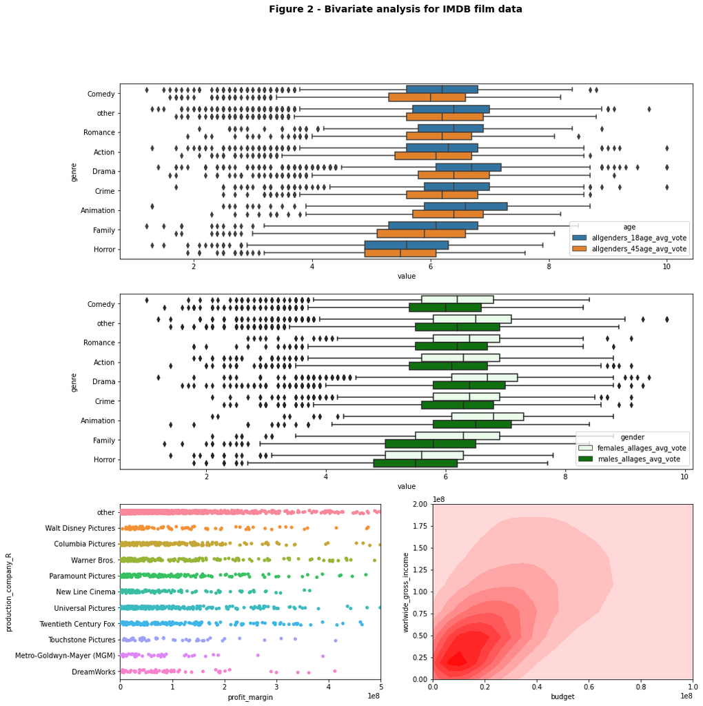

```python
#bivariate analysis
#use data exploded on genre to evaluate demographic rating choices
#subset data for box-plots gender
box_plots_data_gender = dbj1_exploded[['imdb_title_id','females_allages_avg_vote', 'males_allages_avg_vote', 'genre']]
#melt dataset to stack table for box-plot gender
box_plots_data_gender = box_plots_data_gender.melt(id_vars=['imdb_title_id', 'genre'], var_name="gender")
#subset data for box-plots age
box_plots_data_age = dbj1_exploded[['imdb_title_id','allgenders_18age_avg_vote', 'allgenders_45age_avg_vote', 'genre']]
#melt dataset to stack table for box-plot age
box_plots_data_age = box_plots_data_age.melt(id_vars=['imdb_title_id', 'genre'], var_name="age")

#Generate figure size as 15x16
fig4 = plt.figure(figsize=(15, 16))
#layout 2cols by 3rows
spec4 = fig4.add_gridspec(ncols=2, nrows=3)

#generate subplots in formation
f4_ax1 = fig4.add_subplot(spec4[0, :])
f4_ax2 = fig4.add_subplot(spec4[1, :])
f4_ax3 = fig4.add_subplot(spec4[2, 1])
f4_ax4 = fig4.add_subplot(spec4[2, 0])

#generate boxplot
sns.boxplot(x = "value",
            y = "genre",
            data = box_plots_data_age,
            #colour by age
            hue = 'age',
            #choose axis
            ax=f4_ax1
           )
sns.boxplot(x = "value",
            y = "genre",
            data = box_plots_data_gender,
            #colour by gender
            hue = 'gender',
            #choose axis
            ax=f4_ax2,
            #select alternative colour
            color='green'
           )
#set $100 million x-limit
f4_ax3.set_xlim(left= 0, right=100000000)
#set $200 million y-limit
f4_ax3.set_ylim(0, 200000000)

#gather subset of data where the profit is over $1000000
sub = dbj1_world_dollars.query("profit_margin > 1000000")

#generate KDE plot
sns.kdeplot(sub["budget"],
              sub["worlwide_gross_income"],
            #choose shading
               shade=True,
            #select axis
             color = 'red',
            ax=f4_ax3
             );
#build strip plot to show proft margin in relation to production company
sns.stripplot(x = "profit_margin",
              y = "production_company_R",
              data=sub,
              #select axis
              ax=f4_ax4
             );
f4_ax4.set_xlim(0, 500000000)

#add a title, select fontsize 14 and bold
fig4.suptitle("Figure 2 - Bivariate analysis for IMDB film data " ,
                 fontsize=14, fontweight='bold'
                  )
#plot figure
plt.show()
```

### Bivariate Analysis

ESDA in Figure 2 helps to reveal whether there are any notable patterns between variables. The boxplots explore differences in the preferences of IMDB users regarding genre. This is important as this information can help production companies to select genres aimed at audience demographics. The boxplots show on average the younger audiences (allgenders_18age_avg_vote) gave more generous ratings with a mean higher than allgenders_aged45_avg_vote. ‘Animation’ and ‘Family’ films were rated more highly by the younger voter. ‘Animation’ has the biggest difference between the average maximum rating given between ages. The second boxplot set shows that on average females consistently give more generous film ratings (females_all_ages_avg_vote). ‘Animation’ and ‘Family’ films display the greatest difference in mean vote and maximum rating between genders. Ignoring the demographic differences within both plots it is possible to identify the highest rated genre is ‘Animation’ (averaging around 6.5) and the lowest rated is ‘Horror’ (averaging around 5.7). The strip-plot illustrates the profit margins of films with reference to their production_company. It is clear from the plot that DreamWorks and MGM have more sporadic successes than Twentieth Century Fox and Warner Brothers, which have a higher frequency of films at different profit levels. The shaded KDE (bottom-right) identifies the ‘hotspot’ for worldwide_gross_income is where the budget is around \$10 million and the worldwide_gross_income is \\$25 million. The KDE leans to the right showing that often the greater budget leads to greater revenue (but not always).

## Unsupervised Learning

```python
#Process for k-means clustering for imdb data
#reset index
dbj1_world_dollars = dbj1_world_dollars.reset_index(drop=True)

#set k-means with 4 clusters
estimator = KMeans(n_clusters = 4)
#fit the k-means model using the raw data
estimator.fit(dbj1_world_dollars[movie_categories])
#set labels
k5_raw = pd.Series(estimator.labels_,
                       index=dbj1_world_dollars.index
                      )

#birch clustering using the raw data
estimator2 = Birch(threshold=0.01, n_clusters=4)
#fit the model suing the raw data
estimator2.fit(dbj1_world_dollars[movie_categories])
#set labels
Birch5_raw = pd.Series(estimator2.labels_,
                       index=dbj1_world_dollars.index
                      )

#All standardised
# Minus mean, divided by std
db_stded = scale(dbj1_world_dollars[movie_categories])
#standardised - k-means
estimator = KMeans(n_clusters = 4)
#fit model using standardised data
estimator.fit(db_stded)
#set labels
k5_std = pd.Series(estimator.labels_,
                       index=dbj1_world_dollars.index
                      )

# Range scaled data fit to k-means
#use minmaxscaler to range scale data
range_scaler = MinMaxScaler()
#transform data to be scaled
db_scaled = range_scaler.fit_transform(dbj1_world_dollars[movie_categories])
#create k-means model for 4 clusters
estimator = KMeans(n_clusters = 4)
#fit the model using scaled data
estimator.fit(db_scaled)
#set labels
k5_scaled = pd.Series(estimator.labels_,
                       index=dbj1_world_dollars.index
                      )

#set up principle component analysis consisting of 2 components from the raw data
pca_estimator = PCA(n_components=2)
#fit PCA using imdb data
components = pca_estimator.fit_transform(dbj1_world_dollars[movie_categories])
#building the 2 PCA components as dataframe
components = pd.DataFrame(components,
                              index = dbj1_world_dollars.index,
                              columns = ["C-1", "C-2"]
                             )

#Now we cluster the two components instead of all the input variables:
#PCA k-means with 4 clusters
estimator = KMeans(n_clusters = 4)
#fit the model
estimator.fit(components)
#set labels
k5_pca = pd.Series(estimator.labels_,
                       index=components.index
                      )
```

```python
#elbow plot generation code testing the k-means model with different values of k
chss = {}
for i in [2, 3, 4, 5, 10]:
    estimator = KMeans(n_clusters=i)
    #fit the model
    estimator.fit(components)
    #generate calinski harabasz score for each iteration
    chs = calinski_harabasz_score(dbj1_world_dollars[movie_categories],
                                  estimator.labels_
                                 )
    chss[i] = chs
```

```python
#createing a dataframe of the standardised data
std_df = pd.DataFrame(db_stded,
                 index = dbj1_world_dollars.index,
                 columns = movie_categories
                )
#groupby the raw data
g = std_df.groupby(k5_raw)
```

```python
from sklearn.metrics import silhouette_samples, silhouette_score
import matplotlib.cm as cm
```

```python
#calculate calinski harabasz score for raw k-means clusters round to 2.d.p
chs_raw = round(calinski_harabasz_score(dbj1_world_dollars[movie_categories],
                                  k5_raw
                                 ), 2)
#calculate calinski harabasz score for std k-means clusters round to 2.d.p
chs_std = round(calinski_harabasz_score(dbj1_world_dollars[movie_categories],
                                  k5_std
                                 ), 2)
#calculate calinski harabasz score for pca k-means clusters round to 2.d.p
chs_pca = round(calinski_harabasz_score(dbj1_world_dollars[movie_categories],
                                  k5_pca
                                 ), 2)
#calculate calinski harabasz score for scaled k-means clusters round to 2.d.p
chs_sca = round(calinski_harabasz_score(dbj1_world_dollars[movie_categories],
                                 k5_scaled
                                 ), 2)
#calculate calinski harabasz score for raw birch clusters round to 2.d.p
chs_raw_birch = round(calinski_harabasz_score(dbj1_world_dollars[movie_categories],
                                  Birch5_raw
                                 ), 2)
```

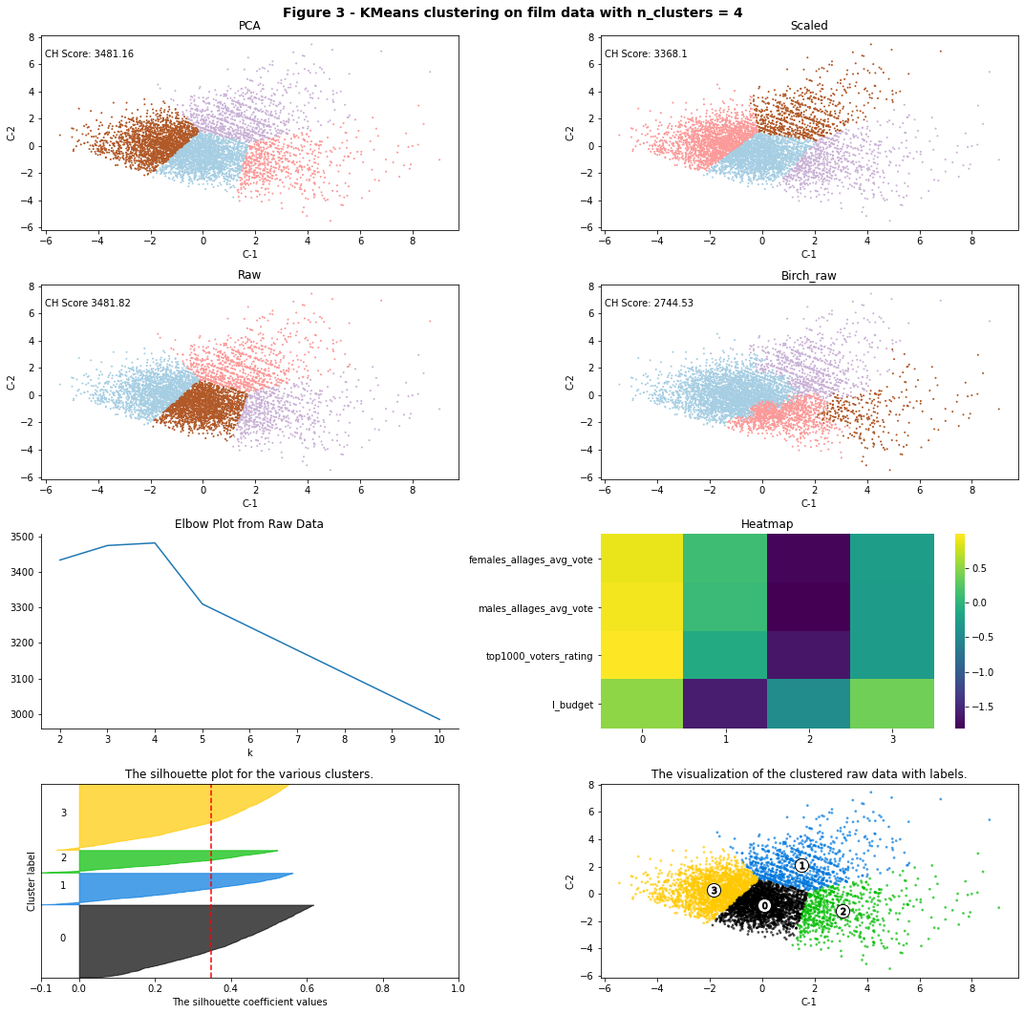

```python
#Generate figure with 4x2 subplots sized 15x15
f, axs = plt.subplots(4, 2, figsize=(15, 15))

#plot PCA data kmeans on first axis
ax = axs[0,0]
components.assign(labels=k5_pca)\
          .plot.scatter("C-1",
                        "C-2",
                        c="labels",
                        s=1,
                        cmap="Paired",
                        colorbar=False,
                        ax=ax
                       )
#Choose title as PCA
ax.set_title("PCA")
#set label of calinski harabasz score
ax.annotate('CH Score: {}'.format(chs_pca), xy=(0.01, 0.89), xycoords='axes fraction')

#plot raw data kmeans
ax = axs[1,0]
components.assign(labels=k5_raw)\
          .plot.scatter("C-1",
                        "C-2",
                        c="labels",
                        s=1,
                        cmap="Paired",
                        colorbar=False,
                        ax=ax
                       )
#Choose title as Raw
ax.set_title("Raw")
#set label of calinski harabasz score
ax.annotate('CH Score {}'.format(chs_raw), xy=(0.01, 0.89), xycoords='axes fraction')

#plot scaled data kmeans
ax = axs[0,1]
components.assign(labels=k5_scaled)\
          .plot.scatter("C-1",
                        "C-2",
                        c="labels",
                        s=1,
                        cmap="Paired",
                        colorbar=False,
                        ax=ax
                       )
#Choose title as Scaled
ax.set_title("Scaled")
#set label of calinski harabasz score
ax.annotate('CH Score: {}'.format(chs_sca), xy=(0.01, 0.89), xycoords='axes fraction')


#plot scaled data kmeans
ax = axs[1,1]
components.assign(labels=Birch5_raw)\
          .plot.scatter("C-1",
                        "C-2",
                        c="labels",
                        s=1,
                        cmap="Paired",
                        colorbar=False,
                        ax=ax
                       )
#Choose title as Birch_raw
ax.set_title("Birch_raw")
#set label of calinski harabasz score
ax.annotate('CH Score: {}'.format(chs_raw_birch), xy=(0.01, 0.89), xycoords='axes fraction')
#generate heatmap and transpose it so it fits better
sns.heatmap(g.mean().T, cmap='viridis', ax=axs[2,1]);
#choose title as Heatmap
axs[2,1].set_title('Heatmap')
#create tidy db restack dataframe used for later steps
tidy_db = std_df\
            .stack()\
            .reset_index()\
            .rename(columns={"level_1": "Var",
                             "level_0": "ID",
                             0: "Value"
                            })\
            .join(pd.DataFrame({"Label": k5_raw}),
                  on="ID")

#use data from calinski harabasz score iterations earlier to gerate an elbow plot
chss = pd.Series(chss)
#choose axis
chss.plot.line(ax=axs[2,0])
#set title
axs[2,0].set_title('Elbow Plot from Raw Data')
#set x label
axs[2,0].set_xlabel('k')
#remove top border
axs[2,0].spines['top'].set_visible(False)
#remove right border
axs[2,0].spines['right'].set_visible(False)


#Process for Silhoutte plot
#set components variable to be an array for Silhouette plot
components_array = components.to_numpy()
#set X to be the array
X = components_array
#set the raw k5 values to be y
y = k5_raw.values
#select 4 clusters for silhoutte plot
range_n_clusters = [4]
#assign axis labels for silhoutte plot
ax1 = axs[3,0]
ax2 = axs[3,1]

#use for loop to cycle through the clusters (in this case just the one for the 4 clusters)
for n_clusters in range_n_clusters:
    # Create a subplot with 1 row and 2 columns
    #fig, (ax1, ax2) = plt.subplots(1, 2)
    #fig.set_size_inches(18, 7)

    # The 1st subplot is the silhouette plot
    # The silhouette coefficient can range from -1, 1 but in this example all
    # lie within [-0.1, 1]
    ax1.set_xlim([-0.1, 1])
    # The (n_clusters+1)*10 is for inserting blank space between silhouette
    # plots of individual clusters, to demarcate them clearly.
    ax1.set_ylim([0, len(X) + (n_clusters + 1) * 10])

    # Initialize the clusterer with n_clusters value and a random generator
    # seed of 10 for reproducibility.
    clusterer = KMeans(n_clusters=4, random_state=10)
    cluster_labels = clusterer.fit_predict(X)

    # The silhouette_score gives the average value for all the samples.
    # This gives a perspective into the density and separation of the formed
    # clusters
    silhouette_avg = silhouette_score(X, cluster_labels)

    # Compute the silhouette scores for each sample
    sample_silhouette_values = silhouette_samples(X, cluster_labels)

    y_lower = 10
    for i in range(n_clusters):
        # Aggregate the silhouette scores for samples belonging to
        # cluster i, and sort them
        ith_cluster_silhouette_values = \
            sample_silhouette_values[cluster_labels == i]

        ith_cluster_silhouette_values.sort()

        size_cluster_i = ith_cluster_silhouette_values.shape[0]
        y_upper = y_lower + size_cluster_i

        color = cm.nipy_spectral(float(i) / n_clusters)
        ax1.fill_betweenx(np.arange(y_lower, y_upper),
                          0, ith_cluster_silhouette_values,
                          facecolor=color, edgecolor=color, alpha=0.7)

        # Label the silhouette plots with their cluster numbers at the middle
        ax1.text(-0.05, y_lower + 0.5 * size_cluster_i, str(i))

        # Compute the new y_lower for next plot
        y_lower = y_upper + 10  # 10 for the 0 samples

    ax1.set_title("The silhouette plot for the various clusters.")
    ax1.set_xlabel("The silhouette coefficient values")
    ax1.set_ylabel("Cluster label")

    # The vertical line for average silhouette score of all the values
    ax1.axvline(x=silhouette_avg, color="red", linestyle="--")

    ax1.set_yticks([])  # Clear the yaxis labels / ticks
    ax1.set_xticks([-0.1, 0, 0.2, 0.4, 0.6, 0.8, 1])

    # 2nd Plot showing the actual clusters formed
    colors = cm.nipy_spectral(cluster_labels.astype(float) / n_clusters)
    ax2.scatter(X[:, 0], X[:, 1], marker='.', s=30, lw=0, alpha=0.7,
                c=colors, edgecolor='k')

    # Labeling the clusters
    centers = clusterer.cluster_centers_
    # Draw white circles at cluster centers
    ax2.scatter(centers[:, 0], centers[:, 1], marker='o',
                c="white", alpha=1, s=200, edgecolor='k')

    for i, c in enumerate(centers):
        ax2.scatter(c[0], c[1], marker='$%d$' % i, alpha=1,
                    s=50, edgecolor='k')

    ax2.set_title("The visualization of the clustered raw data with labels.")
    ax2.set_xlabel("C-1")
    ax2.set_ylabel("C-2")

    #add a title, select fontsize 14 and bold
    plt.suptitle(("Figure 3 - KMeans clustering on film data "
                  "with n_clusters = %d" % n_clusters),
                 fontsize=14, fontweight='bold')
#ensure layout is clean
f.tight_layout()
#plot figure
plt.show()
```

```python
#Matrix of values for each cluster
labels = pd.Series(cluster_labels)
#set dataframe of imdb data grouped by cluster labels
g = dbj1_world_dollars[movie_categories].groupby(labels)
g.size()\
 .sort_values()
#generate the average
g2 = g.mean()
#take exponent of log transformed budget value
g2['budget']= exp(g2['l_budget'])
#round to 2 decimal places
g2 = g2.round(2)
#rename axis with Table 1 label
g2 = g2.rename_axis('TABLE 1 - CLUSTER MATRIX', axis=1)
g2
```

| TABLE 1 - CLUSTER MATRIX | females_allages_avg_vote | males_allages_avg_vote | top1000_voters_rating | l_budget | budget |
| --- | --- | --- | --- | --- | --- |
| 0 | 6.00 | 5.74 | 5.31 | 17.07 | 25893554.83 |
| 1 | 6.42 | 6.16 | 5.51 | 13.88 | 1061526.18 |
| 2 | 4.45 | 4.05 | 3.92 | 15.69 | 6496264.96 |
| 3 | 7.20 | 7.07 | 6.60 | 17.30 | 32595551.80 |

### K-means Clustering

The unsupervised learning method chosen for this report was K-means clustering. It is used to classify the films into natural groupings where the Euclidean distance formula is used to make the clusters from data provided to the algorithm (Meenakshi et al., 2018). The variables chosen for clustering were those pertaining to film ratings and budget ('females_allages_avg_vote','males_allages_avg_vote', 'top1000_voters_rating', 'l_budget').

As K-means uses distance measures between examples it is good practice to standardise or scale data prior to clustering. In this study a model has been fitted for the scaled and raw data to illustrate the best outcome. Principal component analysis (PCA) was performed to summarise the chosen variables into 2 summary variables. This facilitates the creation of a scatter plot with these PCA variables on the x-axis and y-axis. K-means clusters for the PCA variables were also calculated. BIRCH clustering is a method primarily used for larger datasets it was also included as a comparison against k-means. In order to evaluate the quality of the clusters the data was plotted and ‘Calinski and Harabasz’ (CH) scores were generated. This score increases as the clusters improve.

### Cluster Evaluation

The graphics in Figure 3 shows there are minor visual differences in the 4 versions of clustering. The clusters of PCA and Raw are both similar in shape and CH score. The scaled data shows a notable difference in the locations of the cluster boundaries and a lower CH score. BIRCH clustering demonstrates fuzzy boundaries confirming that k-means is a stronger choice of algorithm in this context. The PCA, Raw and Scaled data have similar CH scores (3300+). The best of all these options is narrowly the Raw data which has the highest CH score of 3481.82.

The elbow method and silhouette plot can be used in order to establish the optimal number of clusters (k). The results of the elbow plot shows that a total of 4 clusters is best as the CH score is highest (3481). The silhouette plot demonstrates how close each point in one cluster is to the neighbouring ones. It identifies all 4 clusters have above average silhouette scores (beyond red line). It shows cluster_3 and cluster_0 contain the greatest number of films. It also identifies a minority of negative scores denoting that some potential incorrect cluster assignment.

## Supervised Learning

The outcome variable for the supervised learning analysis is l_worlwide_gross_income. Multivariate linear regression was used to generate prediction models.

### Selection of predictor variables

Correlation tests were conducted to assist predictor variable selection. The results from these tests are documented in Appendix B. The results supported the findings in literature that rating (top1000_voters_rating), genre (Action), budget and the presence of a star_actor are good candidates. Using these variables, a baseline linear regression model and a subsequent augmented model was generated and compared (Table 2).

```python
#linear regression - The Econometrician way
#log price - baseline model - function
f = "np.log1p(worlwide_gross_income) ~ l_budget + top1000_voters_rating + star_actor"
#fit the linear model
lm_log_m1 = sm.ols(f, dbj1_world_dollars)\
       .fit()

#raw price model function
f = "worlwide_gross_income ~ budget + top1000_voters_rating + star_actor"
#fit the model
lm_raw = sm.ols(f, dbj1_world_dollars)\
       .fit()
# establish X-variables for later model creation
X = dbj1_world_dollars[["l_budget" , "top1000_voters_rating" , "star_actor"]]
```

```python
#generate series to summarise linear model results: R-squared, AIC and f_test
lm_log_m1_info = pd.Series({"R-Squared": lm_log_m1.rsquared,
               "AIC": lm_log_m1.aic,
               "f_test": lm_log_m1.f_pvalue
              })
#change to dataframe to join
lm_log_m1_info = lm_log_m1_info.to_frame(name='Baseline')
#change paramaters to dataframe to join
lm_log_m1_df = lm_log_m1.params.to_frame(name='Baseline')
#concatenate tables
lm_model = pd.concat([lm_log_m1_info,lm_log_m1_df])
lm_model = lm_model.round(3)
```

```python
#random forests
#generate random forest with the raw data use 100 estimators
rf_raw = RandomForestRegressor(n_estimators=100,
                               max_features=None
                              )
#fit model
%time rf_raw.fit(X, dbj1_world_dollars["worlwide_gross_income"])
#generate labels used in later dataframe
rf_raw_lbls = rf_raw.predict(X)
#set up log version of random forest using 100 estimators
rf_log = RandomForestRegressor(n_estimators=100,
                               max_features=None
                              )
#fit the model
rf_log.fit(X, np.log1p(dbj1_world_dollars["worlwide_gross_income"]))
#generate labels
rf_log_lbls = rf_log.predict(X)

#generate dataframe with regression model results
res = pd.DataFrame({"LM-Raw": lm_raw.fittedvalues,
                        "LM-Log": lm_log_m1.fittedvalues,
                        "RF-Raw": rf_raw_lbls,
                        "RF-Log": rf_log_lbls,
                        "Truth": dbj1_world_dollars["worlwide_gross_income"]
                       })

#Specify columns to use
cols = ['l_budget','top1000_voters_rating','star_actor']

#save dataframe as a checkpoint
res.to_parquet("../data/lm_results.parquet_imdb")
```

```
Wall time: 648 ms
```

```python
#generate altered model with extra predictor variable - Action
m3 = sm.ols('l_worlwide_gross_income ~ l_budget + top1000_voters_rating + star_actor + Action', dbj1_world_dollars).fit()
```

```python
#generate series to summarise linear model results: R-squared, AIC and f_test
m3_info = pd.Series({"R-Squared": m3.rsquared,
               "AIC": m3.aic,
               "f_test": m3.f_pvalue
              })
#change to dataframe to join
m3_info = m3_info.to_frame(name='Augmented')
#change paramaters to dataframe to join
m3_df = m3.params.to_frame(name='Augmented')
#concatenate tables
lm_m3 = pd.concat([m3_info,m3_df])
#rename axis with Table 2 label, round to 3.dp and join to lm_model
lm_m3 = lm_m3.round(3)
lm_m3 = lm_m3.join(lm_model)
lm_m3 = lm_m3.rename_axis('TABLE 2 - BASELINE MODEL SUMMARY', axis=1)
lm_m3
```

| TABLE 2 - BASELINE MODEL SUMMARY | Augmented | Baseline |
| --- | --- | --- |
| R-Squared | 0.604 | 0.604 |
| AIC | 23905.308 | 23905.848 |
| f_test | 0.000 | 0.000 |
| Intercept | -8.004 | -7.920 |
| l_budget | 1.235 | 1.227 |
| top1000_voters_rating | 0.677 | 0.681 |
| star_actor | 0.307 | 0.298 |
| Action | -0.097 | NaN |

### Model Summary

```python
#Use star wars episode 1 as a sample to predict using model
star_wars = dbj1_world_dollars.loc[dbj1_world_dollars['original_title']=='Star Wars: Episode I - The Phantom Menace', :]
imdb_title_id = star_wars.index[0]
```

```python
%%time
# Parameters
## Number of simulations
r = 200
# Pull out characteristics for house of interest
x_i = dbj1_world_dollars.loc[imdb_title_id, cols]
# Specify model engine
model = lm_log_m1

# Place-holder
sims = np.zeros(r)

# Loop over number of replications
for i in range(r):
    # Get a random draw of betas
    rbs = np.random.normal(model.params, model.bse)
    # Get a random draw of epsilon
    re = np.random.normal(0, model.scale)
    # Obtain point estimate
    y_hr = rbs[0] + np.dot(x_i, rbs[1:]) + re
    # Store estimate
    sims[i] = y_hr

#values needed to plot the confidence intervals on later KDE plot
lo, up = pd.Series(sims)\
               .sort_values()\
               .iloc[[int(np.round(0.025 * r)), int(np.round(0.975 * r))]]
```

```
Wall time: 90 ms
```

```python
# Parameters
## Number of observations & simulations
n = dbj1_world_dollars.shape[0]
r = 200
# Specify model engine
model = lm_log_m1
```

```python
# use number of values from dataframe and number of simulations
sims2 = np.zeros((n, r))
# Loop over number of replications
for i in range(r):
    # Get a random draw of betas
    rbs = np.random.normal(model.params, model.bse)
    # Get a random draw of epsilon
    re = np.random.normal([0]*n, model.scale)
    # Obtain point estimate
    y_hr = rbs[0] + np.dot(dbj1_world_dollars[cols], rbs[1:]) + re
    # Store estimate
    sims2[:, i] = y_hr
```

[figure not shown]

```python
#Generate figure with 3 subplots and figure size 16x6
f, axs = plt.subplots(1,3, figsize=(16, 6))

#generate kde plots
#kde plot for simulations
sns.kdeplot(sims, shade=True, ax=axs[0], label='Simulation')
#kde for observed values
axs[0].axvline(dbj1_world_dollars.loc[imdb_title_id, 'l_worlwide_gross_income'], c='orange', label='Observed')
#kde for predicted values
axs[0].axvline(model.fittedvalues[imdb_title_id], c='green', label='Predicted')

#generate line for lower confidence interval
axs[0].axvline(lo, c='grey', linewidth=1)
#generate line for higher confidence interval
axs[0].axvline(up, c='grey', linewidth=1)
#add legend
axs[0].legend()

#kde plot for comparing observed values and predicted values from 2 iterations of the model
#plot observed
sns.kdeplot(dbj1_world_dollars['l_worlwide_gross_income'], shade=True, ax=axs[1], label='$y$')
#plot baseline model predictions
sns.kdeplot(lm_log_m1.fittedvalues, shade=True, ax=axs[1], label='$\hat{y}_1$')
##

#plot to show simulations
#plot observed distribution kde
sns.kdeplot(dbj1_world_dollars['l_worlwide_gross_income'], shade=True, ax=axs[2], label='$y$')
#plot baseline predictions
sns.kdeplot(lm_log_m1.fittedvalues, shade=True, ax=axs[2], label='$\hat{y}$')
#plot simulations exploring error in the model
for i in range(r):
    sns.kdeplot(sims2[:, i], ax=axs[2], linewidth=0.1, alpha=0.1, color='k')

#add a title, select fontsize 14 and bold
f.suptitle("Figure 4 - Distribution of observed and predicted worldwide revenue ",
                 fontsize=14, fontweight='bold'
                  )
plt.show()
```

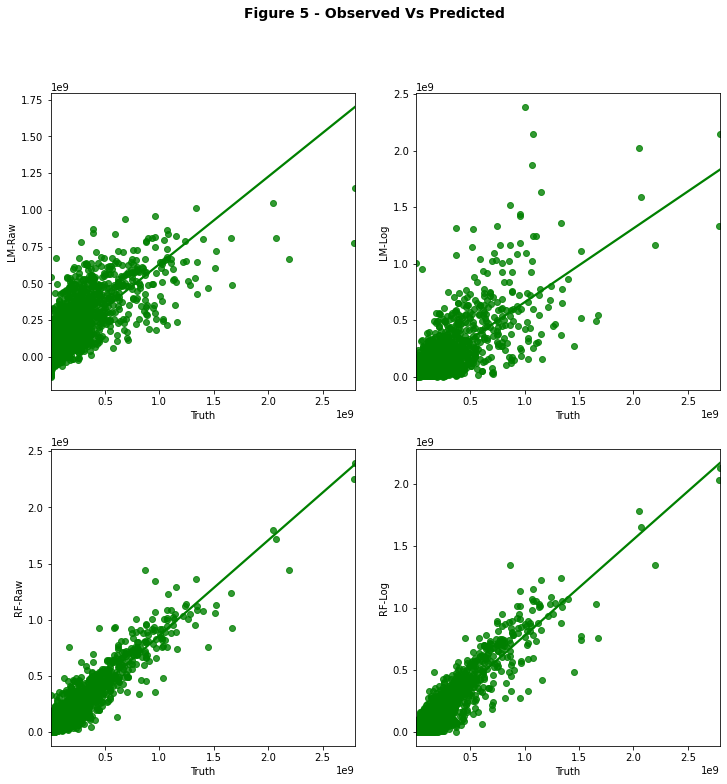

```python
#Generate a copy of the res table in order to correctly plot the exponent on the Observed vs Predicted figure
res2 = res.copy()
#generate exponent of log transformed vals - Linear Model
res2['LM-Log'] = exp(res2['LM-Log'])
#generate exponent of log transformed vals - Random Forest
res2['RF-Log'] = exp(res2['RF-Log'])

#Generate figure 2x2 and figure size 12x12
f, axs = plt.subplots(2, 2, figsize=(12, 12))

#take a list of nested lists and convert it into a structure that contains no nested lists
axs = axs.flatten()
for i, m in enumerate(res2.columns.drop("Truth")):
    ax = axs[i]
    sns.regplot("Truth",
                m,
                res2,
                #set colour as green
                color = 'green',
                ci=None,
                ax=ax
               )

#add a title, select fontsize 14 and bold
f.suptitle("Figure 5 - Observed Vs Predicted",
                 fontsize=14, fontweight='bold')
#show plot
plt.show()
```

### Observed vs Predicted

Figure 5 shows how the data points follow the model best fit line for the linear models (LM) using the raw data and transformed. As a contrast to the LM approach a Random forest (RF) model was generated on the same data. RF are an alternative algorithmic form of supervised learning, they are a collection of decision trees that use a ‘ensemble’ approach to predict an outcome variable. A model generated via RFs can better account for the impact of outliers.

```python
#rebrought into process due to attribute naming conflict
from sklearn.metrics import mean_squared_error as mse
```

```python
#Join the results dataframe (res) to the core imdb data table
db = dbj1_world_dollars.join(res)

#create a series containing the r-sqaured values for each RF and LM
r2s = pd.Series({"LM-Raw": r2_score(db["Truth"],
                                        db["LM-Raw"]
                                       ),
                     "LM-Log": r2_score(log1p(db["Truth"]),
                                        db["LM-Log"]
                                       ),
                     "RF-Raw": r2_score(db["Truth"],
                                        db["RF-Raw"]
                                       ),
                     "RF-Log": r2_score(log1p(db["Truth"]),
                                        db["RF-Log"]
                                       ),
                    })
#change series to be a dataframe
df = r2s.to_frame()
#rename the column
df = df.rename(columns = {0:'r2'})
```

```python
#Perform train test split with 60% of the data as the test size and 40% unseen
x_train, x_test, y_train, y_test = train_test_split(X,
                                                    db["worlwide_gross_income"],
                                                    test_size=0.6
                                                   )

lm_estimator = LinearRegression()
# Fit on X/Y train
lm_estimator.fit(x_train, y_train)
# Predict on X test
lm_y_pred = lm_estimator.predict(x_test)
# Evaluate on Y test
mse_tt = sqrt(mse(y_test, lm_y_pred))
```

```python
#Generate cross validation score for 5 iterations for the linear model
#run cross validation
lm_kcv_mses = cross_val_score(LinearRegression(),
                              X,
                              db["worlwide_gross_income"],
                              cv=5,
                              scoring="neg_mean_squared_error"
                             )
# sklearn uses neg to optimisation is alway maximisation
lm_cv = sqrt(-lm_kcv_mses).mean()

#Generate cross validation score for 5 iterations for the random forest model
#run random forst 100 estimators
rf_estimator = RandomForestRegressor(n_estimators=100,
                                     max_features=None
                                    )
#Generate 5 cross validation for random forest
rf_kcv_mses = cross_val_score(rf_estimator,
                              X,
                              db["worlwide_gross_income"],
                              cv=5,
                              scoring="neg_mean_squared_error"
                             )
# sklearn uses neg to optimisation is alway maximisation
rfe_cv = sqrt(-rf_kcv_mses).mean()
```

```python
#Generate summary table that includes MSE values and R-Squred for various models and their iterations

mse_df = pd.Series({"MSE_TT": mse_tt,
                    "LM-CV": lm_cv,
                    "RF-CV": rfe_cv,
                    "LM-Raw": sqrt(mse(db["Truth"],
                                    db["LM-Raw"])
                                   ),
                      "LM-Log": sqrt(mse(db["Truth"],
                                    exp(db["LM-Log"])
                                   )),
                      "RF-Raw": sqrt(mse(db["Truth"],
                                    db["RF-Raw"]
                                   )),
                      "RF-Log": sqrt(mse(db["Truth"],
                                    exp(db["RF-Log"])
                                   ))
                    })
#make series a dataframe
mse_df = mse_df.to_frame(name = 'MSE')
#sort the values by MSE value
mse_df = mse_df.sort_values(by='MSE')
#generate a column that illustrates the difference in errors between the models
mse_df['MSE Difference from Baseline'] =   mse_df['MSE'] - sqrt(mse(db["Truth"], db["LM-Raw"]))
#join the dataframe with the r-squared value
mse_df = mse_df.join(df)
#generate a column that illustrates difference in r2 value
mse_df['r2 Difference from Baseline'] =   mse_df['r2'] - r2_score(db["Truth"], db["LM-Raw"])
#rename axis
mse_df = mse_df.rename_axis('TABLE 3 - MSE VALUES AND R-SQUARED', axis=1)
#show dataframe
mse_df.round(3)
```

| TABLE 3 - MSE VALUES AND R-SQUARED | MSE | MSE Difference from Baseline | r2 | r2 Difference from Baseline |
| --- | --- | --- | --- | --- |
| RF-Raw | 5.975257e+07 | -5.627848e+07 | 0.893 | 0.298 |
| RF-Log | 6.907352e+07 | -4.695753e+07 | 0.814 | 0.219 |
| LM-Log | 1.160269e+08 | -4.136474e+03 | 0.604 | 0.009 |
| LM-Raw | 1.160311e+08 | 0.000000e+00 | 0.595 | 0.000 |
| RF-CV | 1.180655e+08 | 2.034488e+06 | NaN | NaN |
| LM-CV | 1.518180e+08 | 3.578697e+07 | NaN | NaN |
| MSE_TT | 1.616902e+08 | 4.565914e+07 | NaN | NaN |

## Conclusion

The ESDA established the production_companies that have had less consistent revenue and which genres are popular with audiences. The unsupervised learning has provided insights into which ‘hit’ movies were best value for money in terms of rating. The supervised learning has shown that with a limited number of predictor variables it is possible to estimate worlwide_gross_income with some degree of success particularly using RF. In order to improve the supervised models in future diagnostics such as checking multicollinearity can be performed and further variables as suggested by literature could be implemented.

### References

Krushikanth, A., M. Jose, S. Motnam, C. Chan, K. Liszka, F. Gregio. 2013. Prediction of Movies Box Office Performance Using Social Media. 2013 IEEE/ACM International Conference on Advances in Social Networks Analysis and Mining (ASONAM 2013). 1209-1214.

Lash, M., K. Zhao. 2016. Early Predictions of Movie Success: The Who, What, and When of Profitability. Journal of Management Information System. 33: 874-903.

Meenakshi, K., G. Maragatham, N. Agarwal, I. Ghosh. 2018. A Data mining Technique for Analyzing and Predicting the success of Movie. Journal of Physics. Conf. Ser. 1000.

Song, J. , S. Hana. 2013. Predicting Gross Box Office Revenue for Domestic Films. Communications for Statistical Applications and Methods. Korea Science. 20(4), pp. 301–309.

## Datasources

kaggle.2020.IMDB Movies extensive dataset. Accessed - 01-02-2021: https://www.kaggle.com/stefanoleone992/imdb-extensive-dataset?select=IMDb+ratings.csv

### Appendix - A

```python
#Appendix A
#combine sihouttee score and chs

ch_scores = pd.Series({"Raw": chs_raw,
               "PCA": chs_pca,
               "Scaled": chs_sca,
               "Birch": chs_raw_birch,
              })

ch_scores = ch_scores.to_frame( name = 'ch_scores')

sil_raw = silhouette_score(dbj1_world_dollars[movie_categories],
                           k5_raw,
                           metric="euclidean"
                          )
sil_pca = silhouette_score(dbj1_world_dollars[movie_categories],
                           k5_pca,
                           metric="euclidean"
                          )
sil_scaled = silhouette_score(dbj1_world_dollars[movie_categories],
                           k5_scaled,
                           metric="euclidean"
                          )
sil_birch_raw = silhouette_score(dbj1_world_dollars[movie_categories],
                           Birch5_raw,
                           metric="euclidean"
                          )

sil_scores = pd.Series({"Raw": sil_raw,
               "PCA": sil_pca,
           "Scaled": sil_scaled,
            "Birch": sil_birch_raw
              })

sil_scores = sil_scores.to_frame( name = 'sil_scores')

scores = sil_scores.join(ch_scores)
scores = scores.rename_axis('TABLE A - CLUSTER QUALITY SCORES', axis=1)

scores
```

| TABLE A - CLUSTER QUALITY SCORES | sil_scores | ch_scores |
| --- | --- | --- |
| Raw | 0.321591 | 3481.84 |
| PCA | 0.322265 | 3481.09 |
| Scaled | 0.313360 | 3365.73 |
| Birch | 0.296926 | 2744.53 |

### Appendix - B

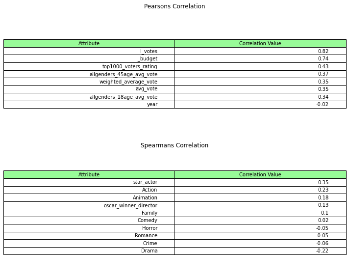

```python
#Appendix B - corellation coefficients

pearsoncorr1 = dbj1_world_dollars[['weighted_average_vote', 'allgenders_18age_avg_vote', 'allgenders_45age_avg_vote', 'l_worlwide_gross_income','year', 'l_budget','l_votes', 'avg_vote','top1000_voters_rating']].corr(method='pearson')
tableA = np.round(pearsoncorr1[['l_worlwide_gross_income']].sort_values(by = 'l_worlwide_gross_income', ascending=False), decimals=2)
tableA = tableA.reset_index()
tableA = tableA.rename(columns={"index":"Attribute","l_worlwide_gross_income":"Correlation Value" })
tableA = tableA[1:]

spearmancorr1 = dbj1_world_dollars[['Drama', 'Action', 'Comedy', 'Animation','Romance','Family','Horror', 'Crime', 'l_worlwide_gross_income', 'star_actor', 'oscar_winner_director']].corr(method='spearman')
tableB = np.round(spearmancorr1[['l_worlwide_gross_income']].sort_values(by = 'l_worlwide_gross_income', ascending=False), decimals=2)
tableB = tableB.reset_index()
tableB = tableB.rename(columns={"index":"Attribute","l_worlwide_gross_income":"Correlation Value" })
tableB = tableB[1:]

fig, axs =plt.subplots(2,1,figsize=(10, 8))
fig.patch.set_visible(False)

the_table = axs[0].table(cellText=tableA.values,colLabels=tableA.columns,loc='center', colColours = ["palegreen"] * 2)
axs[0].axis('off')
axs[0].set_title('Pearsons Correlation')

the_table = axs[1].table(cellText=tableB.values,colLabels=tableB.columns,loc='center', colColours = ["palegreen"] * 2)
axs[1].axis('off')
axs[1].set_title('Spearmans Correlation')
axs[1].axis('tight')

fig.tight_layout()
plt.show()
```

```python
#option to choose to not to use scientific notation
pd.set_option('display.float_format', lambda x: '%.3f' % x)
```